# Does Strategy Diffuse Through Consultant Networks?

Replicating Nyhan & Montgomery (2015) with CLEAN

Zihuan Feng

2026-03-01

# Part I — Replication Results

## The Paper and the Identification Problem

**Nyhan & Montgomery (2015), *AJPS***

- Candidates linked through shared consultants adopt similar campaign strategies.
- Core claim: evidence of **strategy diffusion**.

$$y = \mathbf{X}\boldsymbol{\beta} + \rho \mathbf{W}y + \boldsymbol{\varepsilon}$$

- **W** — row-normalized matrix of shared consultant ties
- **ρ > 0** — candidate’s strategy resembles her network neighbors’
- Published results: $\rho = 0.105^{*}$ (risk-taking), $\rho = 0.346^{***}$ (issue ownership)

**The identification challenge**

Is ρ genuine diffusion — or **latent homophily**?

> Similar candidates (same party, region, ideology) hire the same consultants *and* run similar campaigns.

## Replication Check

| Model | Published ρ | Replicated ρ | Match |
| --- | --- | --- | --- |
| (1) Risk-taking | 0.105 | 0.105 | ✓ |
| (2) Risk-taking + CFscore | 0.078 | 0.078 | ✓ |
| (3) Issue ownership | 0.346 | 0.346 | ✓ |
| (4) Issue ownership + CFscore | 0.350 | 0.350 | ✓ |

## Block Structure Detected by the SBM

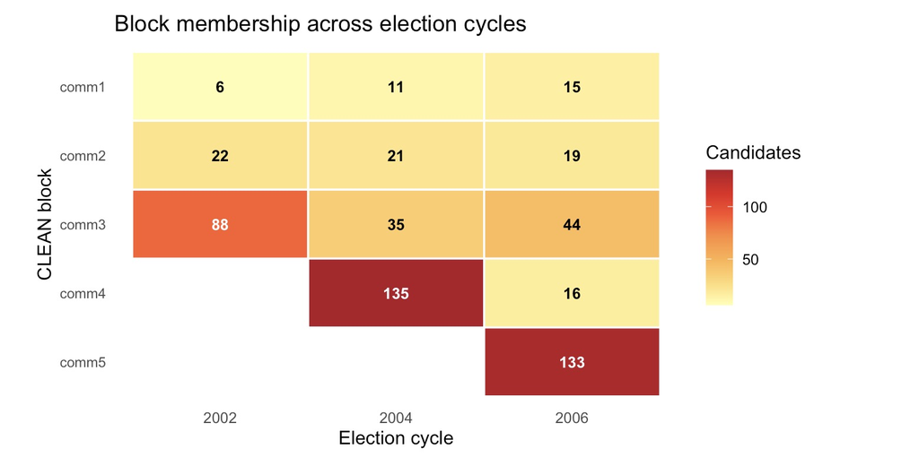

**Estimated block partition**

## Candidate Networks — Nodes Colored by CLEAN Block

**2002 — 3 blocks**

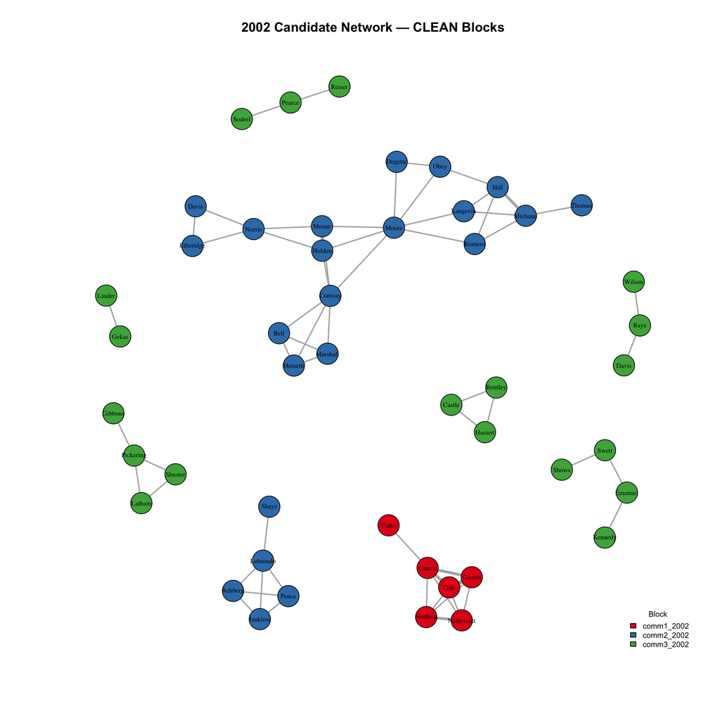

One dominant component; one tight clique; scattered periphery

**2004 — 4 blocks**

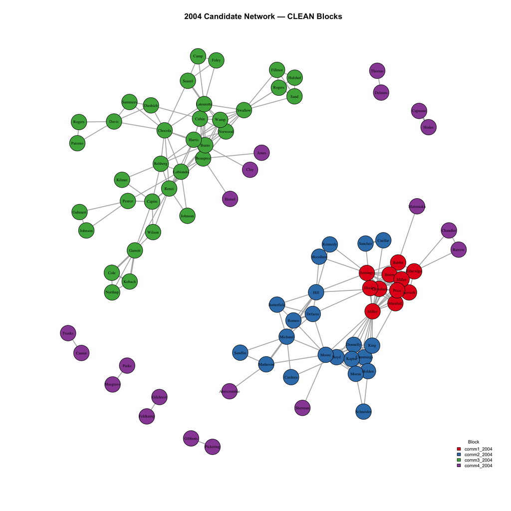

Two fully disconnected components, no cross-ties between consulting ecosystems

**2006 — 5 blocks**

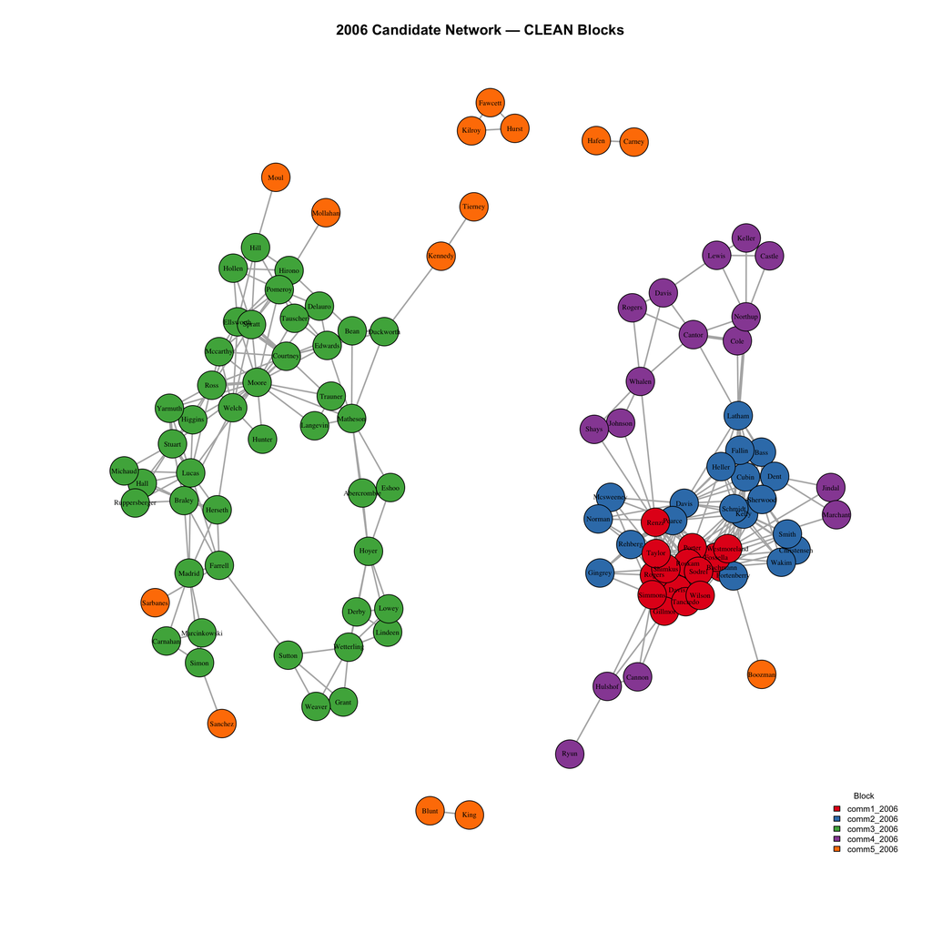

Network grows; block differentiation increases; new isolate cluster emerges

## Collinearity: How Much of Wy Reflects Block Membership?

**Method:** Regress $Wy$, weighted average of neighbors’ strategies, on CLEAN block dummies alone.

|  | $Wy$: Risk-taking | $Wy$: Issue Ownership |
| --- | --- | --- |
| $R^{2}$ | **0.413** | **0.757** |
| Adj. $R^{2}$ | 0.400 | 0.752 |

**Risk-taking: $R^{2} = 0.41$**

Block membership explains 41% of the variation.

**Issue ownership: $R^{2} = 0.76$**

The original ρ was, in part, capturing block-level clustering rather than diffusion. The CLEAN correction is empirically warranted — especially for issue ownership.

## The Main Result

|  | Orig. ρ (SE) | CLEAN ρ (SE) | Change |
| --- | --- | --- | --- |
| **(1) Risk** | $0.105^{*}$ (0.048) | $0.096^{+}$ (0.056) | −9%, remains marginal |
| **(2) Risk + CFscore** | $0.078^{+}$ (0.048) | $0.069$ (0.056) | −12%, **loses significance** |
| **(3) Issue ownership** | $0.346^{***}$ (0.046) | $0.126^{+}$ (0.065) | **−64%**, barely marginal |
| **(4) Issue own. + CFscore** | $0.350^{***}$ (0.047) | $0.129^{+}$ (0.065) | **−63%**, barely marginal |

$^{+}p < 0.10$ $^{*}p < 0.05$ $^{**}p < 0.01$ $^{***}p < 0.001$

**Risk-taking:** partial confounding. ρ declines modestly; some genuine diffusion may persist.

**Issue ownership:** severe confounding. The flagship $\rho = 0.346^{***}$ falls to $0.126^{+}$ — a 63% reduction, no longer conventionally significant.

The most prominent finding in Nyhan & Montgomery (2015) is substantially attenuated once latent homophily is accounted for.

## Why This Replication Is a Strong CLEAN Test Case

**Conditions for confounding are present**

- Party committees and referral networks channel similar candidates
- → homophily is built into the market structure
- Consulting markets segment by party, region, and ideology
- → exactly the block structure SBM is designed to detect

**Data structure suits the method**

- Ties = shared-consultant counts (integers ≥ 0) → Poisson SBM is a natural fit
- No cross-cycle ties → each election year is a clean network

## Why This Replication Is a Strong CLEAN Test Case

**Confounding is confirmed empirically**

- $R^2 = 0.76$: block dummies alone explain 76% of variation in $Wy$ for issue ownership
- → Conditions for severe bias are quantitatively satisfied
- → the correction is warranted

**Bottom line**

- ρ falls by 63% after correction
- homophily confounding was real, large, and detectable.

The paper is a strong CLEAN application: plausible mechanism, appropriate data structure, and empirically confirmed confound.

# Part II How This Was Made

## How to Produce a QMD draft

The entire replication was produced from a single command

`/clean-replicate`

The workflow is described on the following slides.

## How to Apply It to Any SAR Paper

**Step 1.** Create a project folder containing the paper PDF and replication data.

**Step 2.** Add the required files:

```
.claude/commands/clean-replicate.md    ← the command skill
CLEAN_main.pdf                         ← CLEAN methodology paper
CLEAN_tutorial_sbm.pdf                 ← SBM implementation tutorial
Replication_paper.pdf                  ← the original paper
data/                                  ← adjacency matrix + regression data
```

**Step 3.** Run two commands in sequence:

```
/init              # Claude reads the repository structure and data files
/clean-replicate   # Follow the guided four-step workflow
```

## The `/clean-replicate` Workflow

Run `/init` first, then `/clean-replicate`. The command pauses at three decision points before generating all outputs automatically.

| Step | What Claude does | What you provide |
| --- | --- | --- |
| **Stop 1** — Read paper | Extracts tables reporting ρ; identifies adjacency type and network structure | Confirm scope and any corrections |
| **Stop 2** — Methodology | Proposes SBM variant, `clean_blocks_by_time()` vs. `clean_blocks()`, random seed | Approve or modify choices |
| **Stop 3** — Networks | Asks about election cycles, node labels, label source, and subgroup filters | Provide four answers |
| **Auto** — Generate QMD | Produces all outputs: replication check · block heatmap · candidate networks · collinearity table · CLEAN models · comparison table | *(automatic)* |
| **Auto** — Update CLAUDE.md | Documents all methodology choices for reproducibility | *(automatic)* |

Let’s see how it works!

## Recommendations for Getting Started

**1. Learn the basics**

- Complete the course recommended by Howard: [Claude Code Tutorial (Free Course)](https://ccforeveryone.com)

**2. Set up your project**

- Download Zihuan’s “Replication with Claude Template” folder
- Replace `Replication_paper.pdf` with your target paper
- Replace the `/data` folder with your replication dataset

**3. Run the workflow**

- Follow the 3-step process to generate the initial QMD file
- Render the QMD locally and debug any errors
- Write down problems you encounter and send your updated `clean-replicate.md` to Zihuan

## Using Claude to Find Replication Papers

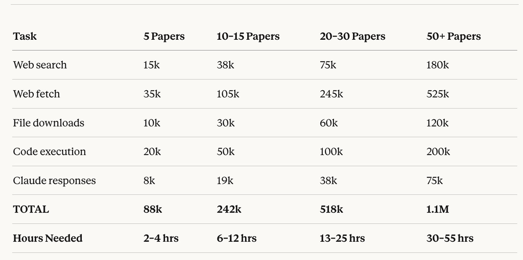

**Cost-Saving Tips**

1. **Search first, download later**
2. **Download datasets manually**
3. **Use `/init` to check fit**

## Future Work

**1. Presentation automation**

- Develop a new SKILL to generate structured slide templates

**2. Reproducibility improvements**

- Address variation in generated code across runs
- the same SKILL can produce different code on repeated executions